# Pilot Data Summary

A Clarke

20/05/2021

# Data check and merge

## Import Data

Data from prolific (data Anna?) and Naa Cato (Alasdair’s MSc student)

```r
d <- read_csv("../pilot_data/pilot_data.csv", col_types = my_cols) %>%
  glimpse() %>%
  mutate(difficulty = as_factor(difficulty),
         difficulty = fct_relevel(difficulty, "easy", "mid", "hard"))
```

```
## Rows: 13,050
## Columns: 7
## $ observer   <chr> "obs1", "obs1", "obs1", "obs1", "obs1", "obs1", "obs1", "ob~
## $ data_from  <chr> "proficio", "proficio", "proficio", "proficio", "proficio",~
## $ trial      <chr> "tex", "tex", "tex", "tex", "tex", "tex", "tex", "tex", "te~
## $ difficulty <chr> "mid", "easy", "easy", "mid", "hard", "hard", "easy", "easy~
## $ targ       <chr> "absent", "absent", "absent", "absent", "present", "present~
## $ rt         <dbl> 5.03, 3.43, 3.21, 3.05, 4.42, 1.08, 7.22, 4.97, 7.41, 6.95,~
## $ accuracy   <dbl> 1, 1, 1, 1, 0, 1, 1, 1, 1, 1, 1, 1, 0, 0, 1, 1, 1, 1, 1, 0,~
```

## Check Summary Stats Between Sites

### Accuracy

From looking at the accuracy data, Naa’s data looks similar to our other pilot data so no reason not to merge.

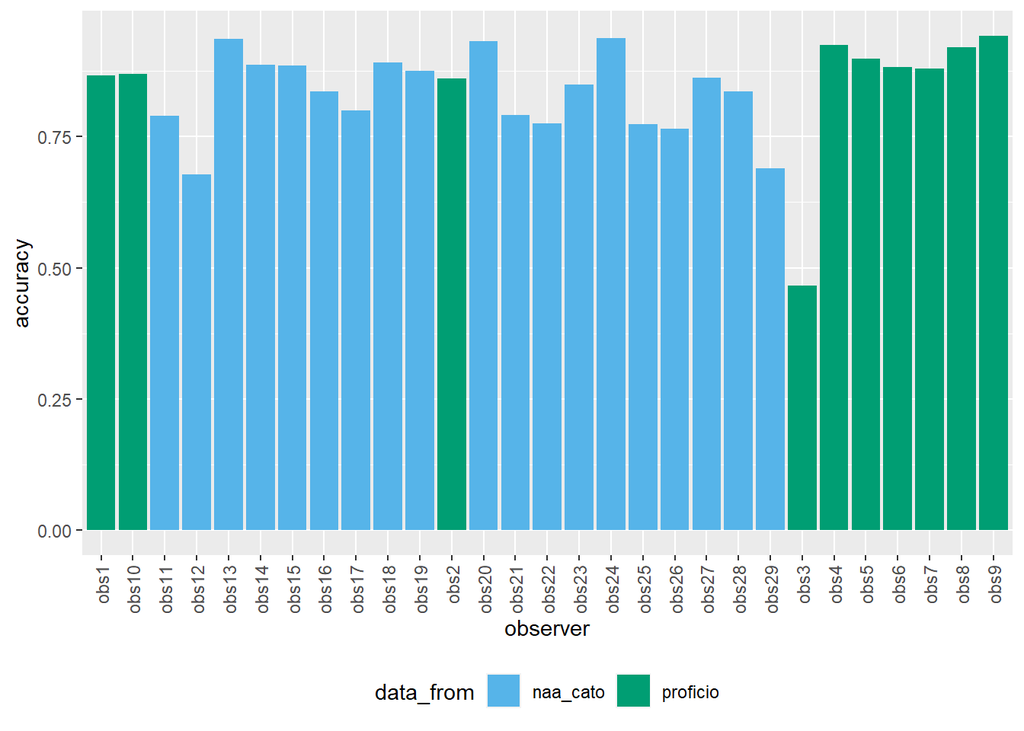

```r
d %>% group_by(observer, data_from) %>%
  summarise(accuracy = mean(accuracy), .groups = "drop") %>%
  ggplot(aes(x = observer, y = accuracy, fill = data_from)) +
  geom_col() +
  theme(legend.position = "bottom",
        axis.text.x = element_text(angle = 90, vjust = 0.5, hjust=1)) +
  ggthemes::scale_fill_pander()
```

Observer 3’s overall accuracy is at chance level, so I suggest we remove

```r
d <- filter(d, observer != "obs3")
```

Now check how people look in the easy condition across tasks.

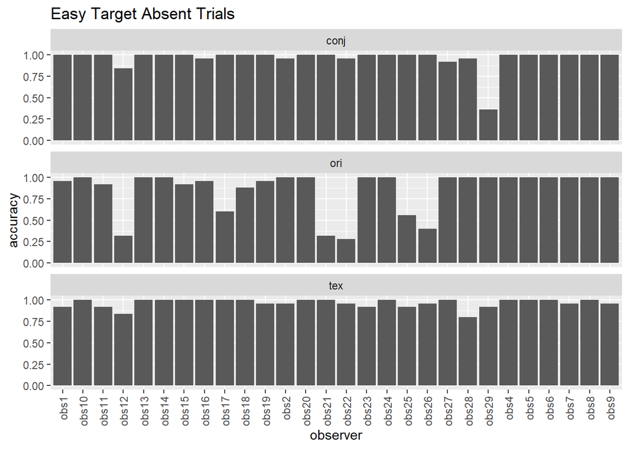

```r
d %>% filter(targ == "absent", difficulty == "easy") %>%
  group_by(observer, difficulty, trial) %>%
  summarise(accuracy = mean(accuracy), .groups = "drop") %>%
  ggplot(aes(x = observer, y = accuracy)) +
  geom_col(position = position_dodge()) +
  facet_wrap(~trial, ncol = 1) +
  theme(legend.position = "bottom",
        axis.text.x = element_text(angle = 90, vjust = 0.5, hjust=1)) +
  ggthemes::scale_fill_pander() +
  ggtitle("Easy Target Absent Trials")
```

Suggested exclusion rule: anybody who scores less than 75% in any one of the three target absent (easy difficulty) conditions.

```r
d %>% filter(targ == "absent", difficulty == "easy") %>%
  group_by(observer, difficulty, trial) %>%
  summarise(accuracy = mean(accuracy), .groups = "drop") %>%
  filter(accuracy < 0.75) %>%
  unite("key", observer, trial) -> to_remove

d %>% unite("key", observer, trial, remove = FALSE) %>%
  filter(!(key %in% to_remove$key)) %>%
  select(-key) -> d

rm(to_remove)
```

### Median Reaction Time

Now we will check that RTs are broadly similar across sites. Remember to only take correct trials!

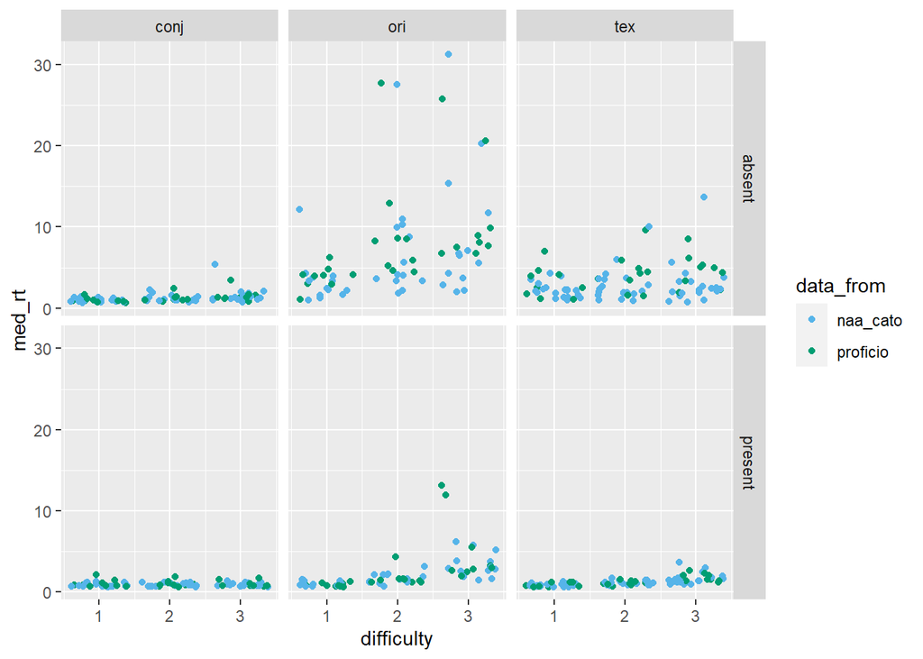

```r
d %>% filter(accuracy == 1) %>%
  group_by(observer, data_from, trial, targ, difficulty) %>%
  summarise(med_rt = median(rt), .groups = "drop") %>%
  mutate(difficulty = as.numeric(difficulty)) %>%
  ggplot(aes(x = difficulty, y = med_rt, colour = data_from)) +
  geom_jitter(height = 0) +
  facet_grid(targ~trial) +
  ggthemes::scale_color_pander()
```

Conclude that it is fine to merge pilot datasets?

## Checking for Outliers

Fancy models can have issues when there are outliers (unless you make an even fancier mixture model!)

Let’s look at the min RT per person

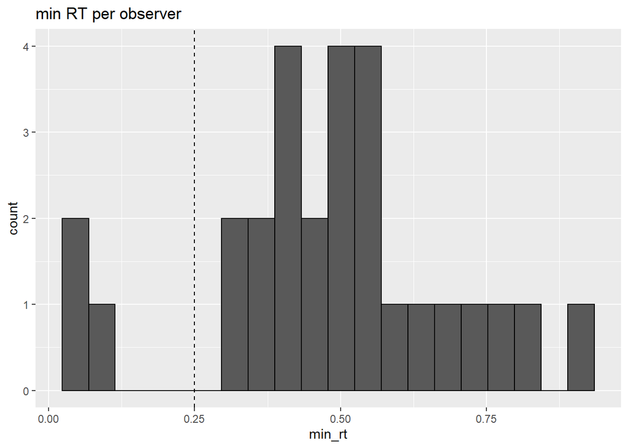

```r
d %>% group_by(observer) %>%
  summarise(min_rt = min(rt), .groups = "drop") %>%
  ggplot(aes(x = min_rt)) + geom_histogram(bins = 20, colour = "black") +
  geom_vline(xintercept = 0.250, linetype = 2) +
  ggtitle("min RT per observer")
```

Removing all RTs < 0.250 seconds seems like a reasonable option

Now let’s look at the max rt…

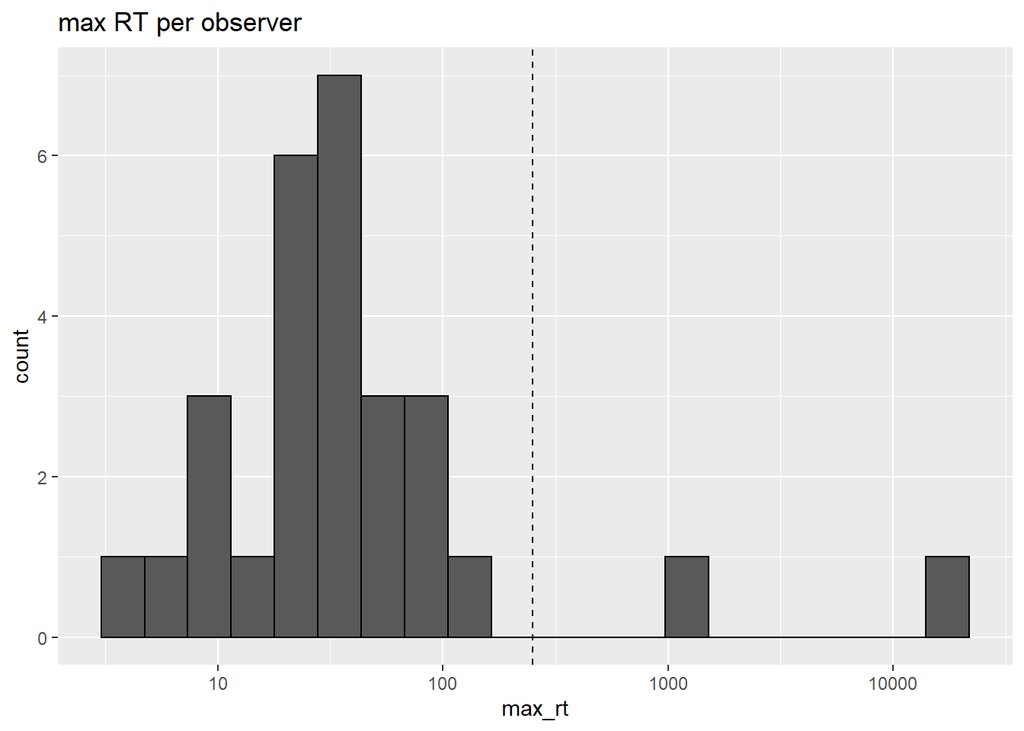

```r
d %>% group_by(observer) %>%
  summarise(max_rt = max(rt), .groups = "drop") %>%
  ggplot(aes(x = max_rt)) + geom_histogram(bins = 20, colour = "black") +
  geom_vline(xintercept = 250, linetype = 2) +
  ggtitle("max RT per observer") +
  scale_x_log10()
```

So perhaps take 250 seconds as our max RT cut off?

How doe these numbers look when compared to the histogram of all RTs.

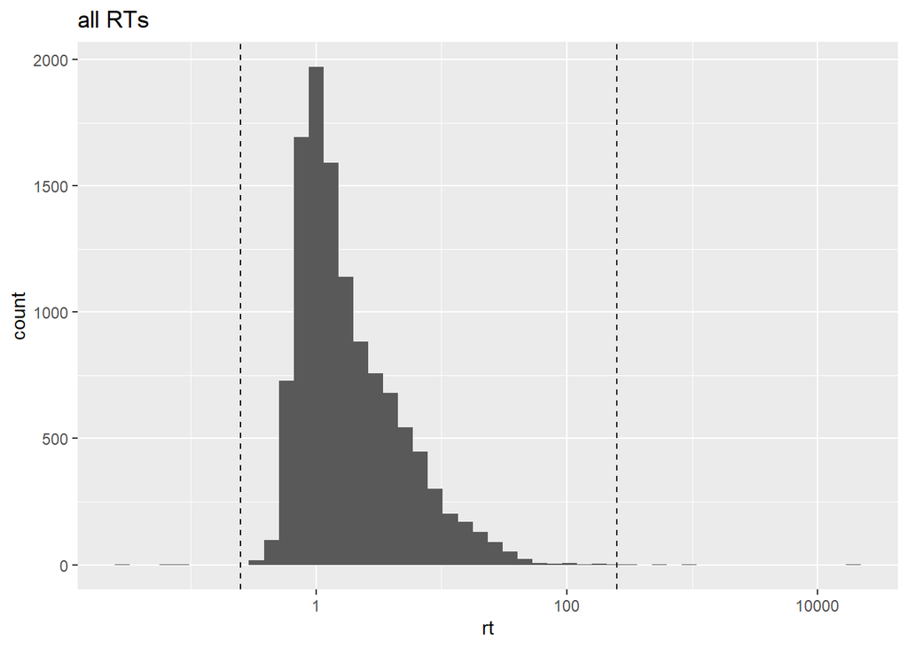

```r
ggplot(d, aes(x = rt)) + geom_histogram(bins = 50) +
  scale_x_log10() +
  geom_vline(xintercept = c(0.250, 250), linetype = 2) +
  ggtitle("all RTs")
```

The above seems reasonable to me.

```r
d %>%
  summarise(percent_below = 100*mean(rt<0.250),
            percent_above = 100*mean(rt>250),
            percent_removed = percent_below + percent_above) %>%
  knitr::kable()
```

| percent_below | percent_above | percent_removed |
| --- | --- | --- |
| 0.03 | 0.05 | 0.08 |

```r
d <- filter(d, rt>0.250, rt<250)
```

## Output for Modelling

Before we run our model, we have to recover the present/absent responses made for each trial (rather than accuracy)

```r
d$response <- NA
d$response[which(d$targ=="present" & d$accuracy==1)] = 1
d$response[which(d$targ=="present" & d$accuracy==0)] = 0
d$response[which(d$targ=="absent" & d$accuracy==1)] = 0
d$response[which(d$targ=="absent" & d$accuracy==0)] = 1
```

Finally, save the data before modelling.

```r
write_csv(d, "../cluster/data_for_model.csv")
```

# Summary Statistics

Let’s see if there is a correlation between accuracy or rt!

## Accuracy

To start with, we’ll ignore *difficulty*

```r
d %>% group_by(trial, targ, observer) %>%
  summarise(accuracy = mean(accuracy), .groups = "drop_last") %>%
  unite("condition", c(trial, targ)) %>%
  pivot_wider(names_from = "condition", values_from = "accuracy") %>%
  select(-observer) %>%
  correlate(method = "pearson", use = "pairwise.complete.obs") %>%
  knitr::kable()
```

```
##
## Correlation method: 'pearson'
## Missing treated using: 'pairwise.complete.obs'
```

| term | conj_absent | conj_present | ori_absent | ori_present | tex_absent | tex_present |
| --- | --- | --- | --- | --- | --- | --- |
| conj_absent | NA | 0.64 | 0.15 | 0.26 | 0.59 | 0.56 |
| conj_present | 0.64 | NA | -0.03 | 0.29 | 0.42 | 0.59 |
| ori_absent | 0.15 | -0.03 | NA | 0.02 | 0.42 | 0.06 |
| ori_present | 0.26 | 0.29 | 0.02 | NA | -0.04 | 0.36 |
| tex_absent | 0.59 | 0.42 | 0.42 | -0.04 | NA | 0.35 |
| tex_present | 0.56 | 0.59 | 0.06 | 0.36 | 0.35 | NA |

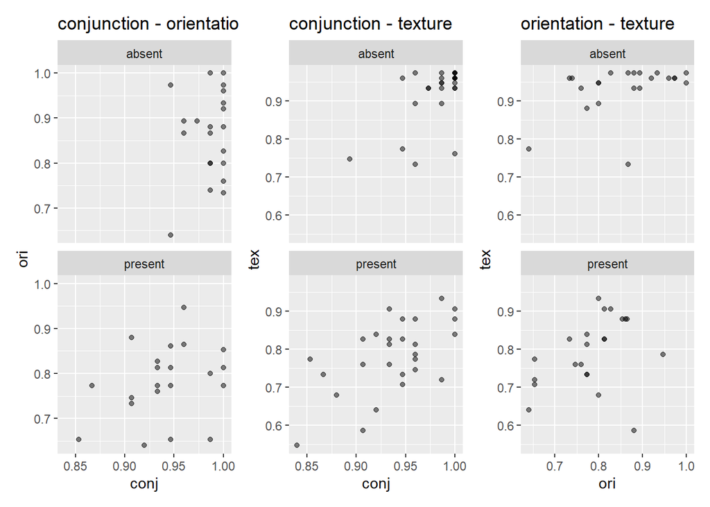

```r
d %>% group_by(trial, targ, observer) %>%
  summarise(accuracy = mean(accuracy), .groups = "drop") %>%
  pivot_wider(names_from = "trial", values_from = "accuracy") -> dplt


plt1 <- ggplot(dplt, aes(x = conj, y = ori)) + geom_point(alpha = 0.5) +
  facet_wrap(~targ, ncol = 1) + ggtitle("conjunction - orientation")

plt2 <- ggplot(dplt, aes(x = conj, y = tex)) + geom_point(alpha = 0.5) +
  facet_wrap(~targ, ncol = 1) + ggtitle("conjunction - texture")

plt3 <- ggplot(dplt, aes(x = ori, y = tex)) + geom_point(alpha = 0.5) +
  facet_wrap(~targ, ncol = 1) + ggtitle("orientation - texture")

plt1 + plt2 + plt3
```

# Modelling

## Forumla

```r
formula <- bf(rt | dec(response) ~
              # the first part is the linear predictor for drift rate
              0 + targ:trial  + targ:trial:difficulty  +
                (0 + targ:trial + targ:trial:difficulty|p|observer),
              # bs: boundary separation
              bs ~ 0 + trial + (0 + trial|p|observer),
              # ndt: non-decision time
              ndt ~ 0 + trial + (1|p|observer),
              # bias: starting bias for TA or TP
              bias ~ 0 + trial + (0 + trial|p|observer))
```

## Prior

Print out list of all priors required for our formula, and any defaults that are already in place:

```r
get_prior(formula,
          data = d,
          family = wiener(link_bs = "log",
                          link_bias = "logit",
                          link_ndt = "log"))
```

Specify some of our own priors for the fixed effects:

```r
prior <- c(
  set_prior("normal(0, 3)", class = "b"),
  set_prior("normal(1.5, 1)", class = "b", dpar = "bs"),
  set_prior("normal(0, 0.01)", class = "sd", dpar = "ndt"),
  set_prior("normal(0.0, 0.5)", class = "b", dpar = "bias"),
  set_prior("normal(-5, 0.5)", class = "Intercept", dpar = "ndt"))
```

## Posterior

The model was fit on the cluster using:

```r
fit_wiener <- brm(formula,
                  data = d,
                  family = wiener(link_bs = "log",
                                  link_bias = "logit",
                                  link_ndt = "log"),
                  prior = prior,
                  inits = initfun,
                  iter = 2000,
                  chains = 1,
                  control = list(max_treedepth = 15, adapt_delta = 0.9))
```

Let’s read in the fitted model

```r
fit_wiener <- readRDS("models/wiener_fit.model")
```

Check rhat statistics are close to 1

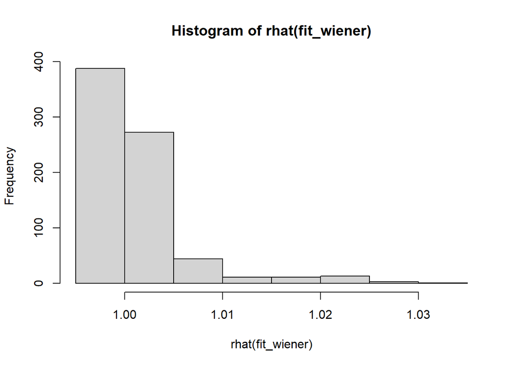

```r
hist(rhat(fit_wiener))
```

### Posterior Predictions

```r
NPRED <- 5
pred_wiener <- predict(fit_wiener,
                       summary = FALSE,
                       negative_rt = TRUE,
                       nsamples = NPRED,
                       re_formula = NULL)
d$p <- as.numeric(apply(pred_wiener, 2, median)) # this is dumb. Fix!
rm(pred_wiener)

## plot accuracy
d %>% mutate(
  p_rt = if_else(targ == "absent", -p, p),
  p_re = if_else(p < 0, 0, 1),
  p_ac = if_else((targ=="present")==p_re, 1, 0)) -> d

d %>%
  group_by(observer, trial, targ, difficulty) %>%
  summarise(
    accuracy = mean(accuracy),
    pred_acc = mean(p_ac)) %>%
  ggplot(aes(x = pred_acc, y = accuracy, colour = difficulty)) +
  geom_abline(linetype = 2) +
  geom_jitter(alpha = 0.5, position = "jitter") +
  geom_smooth(method = "lm", formula = y~x, aes(group = 1), colour = "grey") +
  facet_grid(targ~trial, scales = "free") +
  ggthemes::scale_colour_ptol()
ggsave("model_pred_acc.png", height = 4, width = 6)


## plot rt
d %>% filter(accuracy == 1) %>%
  group_by(observer, trial, targ, difficulty) %>%
  summarise(empirical = median(rt)) -> ed

d %>% filter(p_ac == 1)  %>%
  group_by(observer, trial, targ, difficulty) %>%
  summarise(model = median(rt)) -> pd

full_join(ed, pd) %>%
  ggplot(aes(x = model, y = empirical, colour = difficulty)) +
  geom_abline(linetype = 2) +
  geom_point(alpha = 0.5) +
  geom_smooth(method = "lm", formula = y~x, aes(group = 1), colour = "grey") +
  facet_grid(targ~trial) +
  coord_fixed() +
  ggthemes::scale_colour_ptol()
ggsave("model_pred_rt.png", height = 4, width = 6)
```

[output not shown]